# Anomalías térmicas en el Parque Nacional Palo Verde — VIIRS NOAA-20

Detecciones del sensor VIIRS a bordo de NOAA-20 (VIIRS_NOAA20_SP de NASA FIRMS)

Autor/a

Organización Incendios Forestales

Fecha de publicación

21 de octubre de 2026

## Introducción

Este reporte presenta las anomalías térmicas (detecciones de fuego activo) registradas por el sensor **VIIRS** a bordo del satélite **NOAA-20** en el [Parque Nacional Palo Verde](https://www.sinac.go.cr/), Costa Rica. Es el tercero de una serie de reportes análogos, junto con los de MODIS (Terra y Aqua, desde 2001) y VIIRS en Suomi-NPP (desde 2012): misma metodología, mismos productos, distinta plataforma de observación.

NOAA-20 lleva **el mismo instrumento** que Suomi-NPP —VIIRS, con píxel de 375 m en las bandas de imagen— pero vuela media órbita por detrás, de modo que pasa sobre el parque unos cincuenta minutos después. No observa los mismos fuegos en los mismos instantes, sino que **añade oportunidades de observación**: un fuego encendido entre ambos pasos aparece en uno y no en el otro. Por eso sus detecciones se publican como serie propia y no se suman a las de Suomi-NPP; sumarlas produciría un salto artificial en 2018, cuando NOAA-20 entra en operación, que reflejaría el número de satélites en órbita y no el régimen de fuego.

El período analizado va del **10/04/2018** al **28/07/2026**, con un total de **339** detecciones dentro del parque.

### Una advertencia sobre el área quemada

A diferencia de MODIS y Suomi-NPP, **NOAA-20 no tiene producto de área quemada**: el equivalente que le correspondería (`VJ164A1`) no ha sido publicado. El único producto de área quemada de la familia VIIRS es **VNP64A1**, derivado de Suomi-NPP.

Este reporte lo usa de todas formas, recortado al período de NOAA-20 y **rotulado como «VNP64A1, S-NPP»** en cada figura, tabla y leyenda donde aparece. Es una decisión defendible porque el área quemada es una medición distinta de la de fuego activo —la superficie que quedó marcada, en píxeles de 500 m— y no detecciones de otro sensor mezcladas con las de este. Pero conviene tenerlo presente al leer: **las hectáreas de este reporte no provienen de NOAA-20**, y cuando se comparan las dos series de un mismo gráfico se están comparando dos plataformas.

## Mapa animado

Detecciones mensuales de anomalías térmicas; el color indica la potencia radiativa del fuego (FRP).

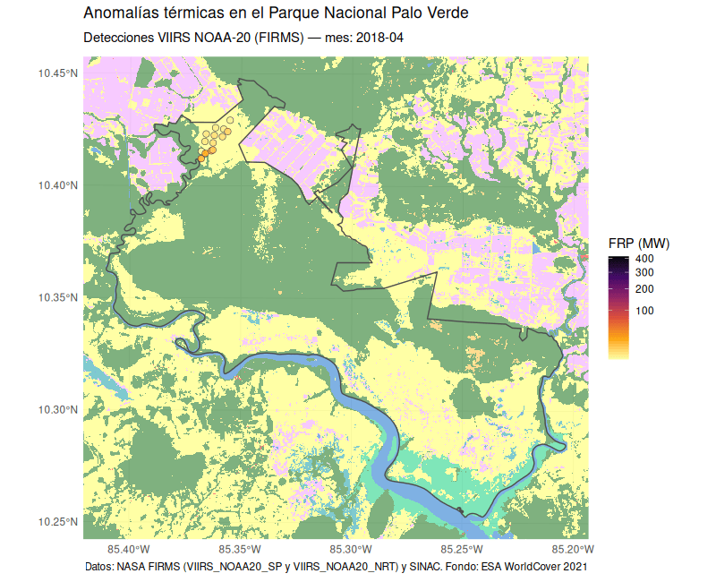

## Video resumen

Resumen mensual en formato de video: detecciones de fuego activo (VIIRS NOAA-20) con su estela de los meses recientes y píxeles de área quemada (VNP64A1, de Suomi-NPP), sobre el relieve del parque teñido por la cobertura de la tierra (WorldCover 2021).

[video not shown]

El cartel estático resume las dos series mensuales del video.

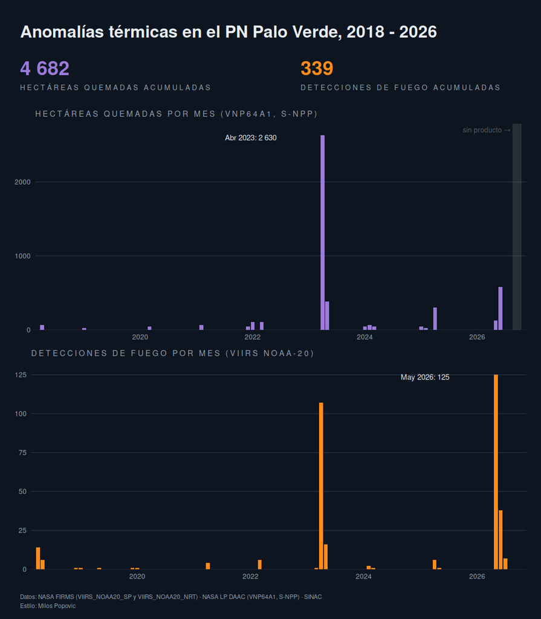

## Mapa interactivo

Use el deslizador temporal para explorar las detecciones a través del tiempo; cada punto muestra sus atributos al pulsarlo, incluida la cobertura de la tierra dominante en su footprint. El botón ⛶ de la esquina superior izquierda abre el mapa en pantalla completa. Como en todos los productos VIIRS, la confianza de cada detección es categórica —baja, nominal o alta— y no un porcentaje como en MODIS.

[interactive chart not shown]

## Estadísticas

### Serie temporal mensual

Detecciones de fuego activo (arriba) y hectáreas quemadas (abajo), con el eje temporal compartido. Las dos series son complementarias y **no sumables**, y en este reporte provienen además de plataformas distintas.

[interactive chart not shown]

### Climatología mensual (estacionalidad)

Promedios por mes calendario de ambas magnitudes.

[interactive chart not shown]

### Resumen anual

| Año | Detecciones | Hectáreas quemadas | FRP promedio (MW) | FRP máximo (MW) |
| --- | --- | --- | --- | --- |
| 2018 | 21 | 64 | 6.8 | 18.01 |
| 2019 | 3 | 21 | 12.6 | 17.95 |
| 2020 | 1 | 43 | 15.1 | 15.06 |
| 2021 | 4 | 107 | 8.4 | 14.65 |
| 2022 | 6 | 214 | 2.7 | 6.18 |
| 2023 | 124 | 3014 | 52 | 413.5 |
| 2024 | 3 | 150 | 3.6 | 5.36 |
| 2025 | 7 | 363 | 15.9 | 21.84 |
| 2026 | 170 | 706 | 11.3 | 68.12 |

### El episodio de mayo de 2026

El mes más activo de todo el registro de NOAA-20 es **mayo de 2026**, con **125** detecciones. Corresponde al incendio del humedal Catalina, que tiene sección propia más abajo porque las cuatro plataformas lo registraron y existe una cifra oficial de superficie con la cual contrastarlo.

Ese episodio tiene además una consecuencia al comparar reportes. Sobre todo el registro, NOAA-20 acumula casi el doble de detecciones que Suomi-NPP, lo que podría leerse como una diferencia de sensibilidad entre plataformas. No lo es: **descontando 2026, la relación baja a aproximadamente 1,2 a 1**, que es lo esperable de un mismo instrumento observando desde dos órbitas con distinta hora de paso. Buena parte de la diferencia aparente proviene de un solo mes con un episodio grande, y de que NOAA-20 lo vio durante cinco días mientras Suomi-NPP lo vio durante tres.

## Cobertura de la tierra

Cada detección corresponde a un píxel de 375 m en el nadir (mayor fuera de él), por lo que la cobertura se caracteriza sobre el *footprint* completo de la detección —una elipse con las dimensiones reales del píxel, columnas `scan` × `track`— y no sobre el punto exacto.

**Limitación**: WorldCover describe la cobertura de 2021, mientras que el registro abarca 2018–2026.

[interactive chart not shown]

El gráfico gemelo muestra las **hectáreas quemadas** según la clase dominante del píxel de VNP64A1 (Suomi-NPP).

[interactive chart not shown]

### Contraste con el Registro Nacional de Humedales

WorldCover clasifica como *pastizal* buena parte de la marisma del parque, así que la clase más frecuente merece una advertencia.

| Clase WorldCover | Detecciones | En humedal | % en humedal | Fracción del footprint en humedal | Hectáreas quemadas | % del área quemada en humedal |
| --- | --- | --- | --- | --- | --- | --- |
| Pastizal | 303 | 295 | 97.4 | 0.881 | 3570 | 95.2 |
| Bosque | 28 | 12 | 42.9 | 0.137 | 684 | 25 |
| Manglar | 6 | 6 | 100 | 0.74 | 192 | 100 |
| Cultivos | 2 | 1 | 50 | 0.5 | 235 | 45.5 |

El resultado es aún más marcado que en los otros dos reportes: el **97,4 %** de las 303 detecciones cuyo footprint domina el *pastizal* caen dentro de un humedal registrado, y en promedio el **88 %** del footprint está cubierto por humedal. Tres plataformas independientes coinciden: **las quemas del «pastizal» ocurren en la marisma, no en potreros.**

**Advertencia sobre la clase de humedal**: el registro asigna una sola clase por polígono, y *Sector Catalina 1* (4 453 ha, clasificado como *Manglar*) cubre casi todo el sector estuarino, por lo que concentra 284 detecciones. Eso **no** significa que esas quemas ocurran en manglar: dentro de ese polígono el manglar cubre apenas el 11,6 % de la superficie según WorldCover y el 4,1 % según la Cobertura Forestal 2023 del SINAC.

## El episodio del humedal Catalina, mayo de 2026

Casi todo lo que este reporte mide carece de contraparte en tierra. El episodio de mayo de 2026 es la excepción: el 28 de mayo de 2026 la caída de un rayo encendió el interior del humedal Catalina, y una semana después Delfino.cr reportaba, con cifras del Minae-Sinac, que el fuego había afectado **cerca de 4 000 hectáreas** ([nota del 3 de junio de 2026](https://delfino.cr/2026/06/incendio-en-parque-nacional-palo-verde-afecto-cerca-de-4000-hectareas)). El combustible principal fue la *Typha*, una planta invasora que arde incluso sobre el agua. Hay entonces una fecha de ignición, una causa y una superficie oficial: tres cosas con las que auditar los productos satelitales.

**Lo que vio esta plataforma.** De las cuatro, NOAA-20 es la que siguió el incendio durante más tiempo: **163 detecciones** en 5 días, del 29 de mayo al 2 de junio de 2026 —el fuego apareció en las imágenes 1 día después de la ignición reportada—, con una potencia radiativa acumulada de 1872 MW y un máximo de 68,1 MW en un solo píxel. 42 de esas detecciones son nocturnas: el fuego no se apagaba de noche. El día pico fue el 31 de mayo, con 59 detecciones.

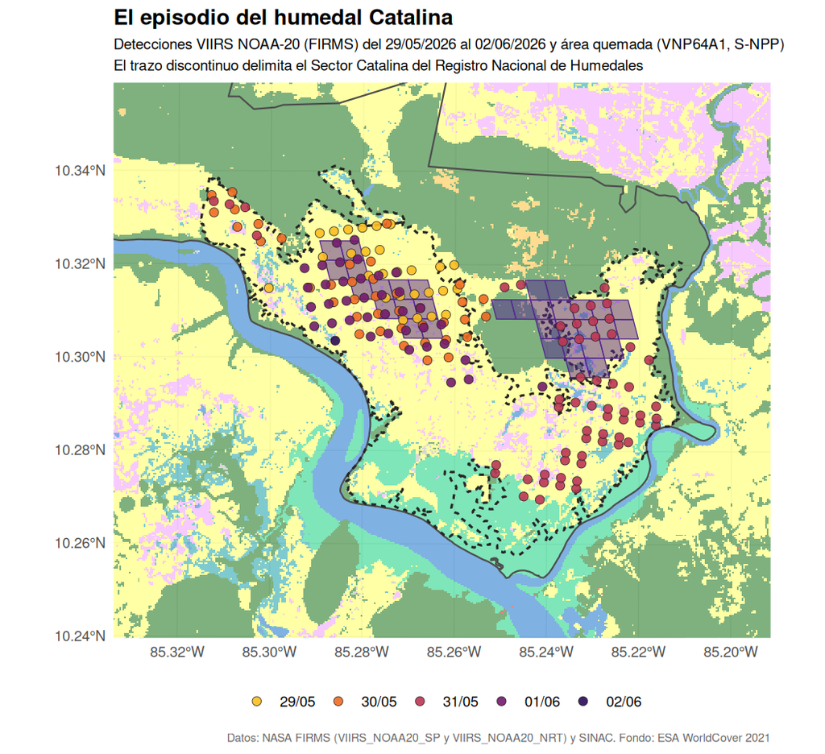

**Dónde ardió.** El **96,9 %** de las detecciones tiene como polígono dominante el *Sector Catalina* del Registro Nacional de Humedales, el mismo sector estuarino de 4 453 ha de la sección anterior, y el **95,7 %** cae en footprints donde WorldCover ve *pastizal*. Es la demostración más nítida de aquel hallazgo: el “pastizal” que arde en Palo Verde no es potrero sino marisma, y esta vez la fuente periodística confirma que lo que ardió fue un typhal sobre agua.

**Lo que el área quemada no vio.** Para mayo y junio de 2026, VNP64A1, S-NPP marca **706 hectáreas** quemadas dentro del parque, frente a las 4 000 reportadas oficialmente: el producto satelital ve **5,7 veces menos superficie** que la contabilizada en tierra. El mapa lo muestra sin necesidad de cifras: las detecciones de fuego activo cubren buena parte del sector, mientras que los píxeles de área quemada forman unas pocas manchas sueltas.

La explicación está en cómo funciona el producto. VNP64A1, S-NPP declara quemado un píxel de 500 m cuando detecta un **cambio persistente de reflectancia**, y una quema de *Typha* sobre lámina de agua no lo produce: la vegetación emergente desaparece, el agua vuelve a dominar la señal y a las pocas semanas la superficie se parece a lo que era antes. A eso se suma que el píxel de 500 m no resuelve las cicatrices delgadas e interrumpidas que deja un fuego que avanza entre canales. No es un defecto de este episodio sino el comportamiento esperable del algoritmo en humedales, y advierte contra leer las hectáreas de la tabla anual como una medida de la superficie realmente afectada: **sirven para comparar años entre sí, no para responder cuántas hectáreas se quemaron.** A la advertencia general de este reporte —que las hectáreas no provienen de NOAA-20 sino de Suomi-NPP— se suma entonces esta otra, que afecta por igual a las cuatro plataformas.

**Nivel de procesamiento**: las detecciones del episodio provienen del procesamiento en estándar —NOAA-20 es la única plataforma cuyo procesamiento estándar ya alcanzó los primeros días del incendio—. El tramo en tiempo casi real se refina cuando la NASA lo reprocesa, de modo que las cifras de los últimos días pueden cambiar retroactivamente.

## ¿El fuego bordea el bosque o lo rodea?

El parque es **54,0 %** bosque y **36,0 %** pastizal según WorldCover, pero solo el **8,3 %** de las detecciones tiene bosque como clase dominante de su footprint, frente al **89,4 %** con pastizal.

Para separar el “efecto de borde” de una ilusión geométrica se compara cada detección contra un modelo nulo: **3000** puntos aleatorios dentro del parque, calculando la fracción de bosque en **500 m** a la redonda.

| Situación paisajística | % de las detecciones | % del área quemada | % esperado por azar |
| --- | --- | --- | --- |
| Abierto (&lt;20 % de bosque alrededor) | 79.9410029498525 | 69.40631744202723 | 33.83333333333334 |
| Borde (20–80 %) | 18.58407079646018 | 26.02745850894894 | 28.2 |
| Interior de bosque (&gt;80 %) | 1.474926253687316 | 4.566224049023837 | 37.96666666666667 |

El resultado es el más extremo de los tres reportes. Las detecciones ocurren en terreno abierto **79,9 %** de las veces contra un 33,8 % esperado por azar, y el interior de bosque prácticamente desaparece: **1,5 %** contra 38,0 % esperado. La mediana de bosque circundante es **0,006** en las detecciones y 0,57 en los puntos aleatorios.

La categoría de borde tampoco está sobrerrepresentada — **18,6 %** contra 28,2 % esperado; aquí la diferencia sí es estadísticamente significativa (*p* = 0,000), pero en el sentido contrario al que supondría un efecto de borde: el fuego aparece en el borde **menos** de lo que cabría esperar por azar. La conclusión de los otros dos reportes se sostiene y se refuerza: **el fuego no bordea el bosque, lo rodea.**

### Por qué no debe leerse como un efecto de la resolución

Es tentador ordenar los tres reportes en una escala y concluir que a mayor resolución, menos fuego de interior: MODIS registra 16,4 % de detecciones en interior de bosque, Suomi-NPP 7,9 % y NOAA-20 1,5 %. La primera comparación sí es un efecto de resolución —el footprint de MODIS supera 1 km² e invade el bosque cuando el fuego arde en la marisma contigua—, pero **la segunda no puede serlo**: Suomi-NPP y NOAA-20 llevan el mismo instrumento con el mismo píxel de 375 m.

La diferencia entre ambas plataformas responde a que observan episodios distintos, y en el caso de NOAA-20 pesa mucho el de mayo de 2026, que aporta casi la mitad de sus detecciones y ocurrió en terreno abierto. Es un recordatorio útil: con registros de unos pocos cientos de detecciones, un solo episodio grande mueve los porcentajes de manera apreciable.

**Limitación**: el modelo nulo supone que cualquier punto del parque tiene la misma probabilidad de arder, lo que ignora factores como la accesibilidad o la cercanía a caminos y linderos.

## Fuentes de datos

- **NASA FIRMS** — Fire Information for Resource Management System, producto VIIRS_NOAA20_SP (VIIRS 375 m, NOAA-20/JPSS-1, procesamiento estándar). https://firms.modaps.eosdis.nasa.gov/. Cita sugerida: Schroeder, W., y Giglio, L. (2018). *VIIRS/JPSS1 Thermal Anomalies/Fire 6-Min L2 Swath 375m*, DOI: 10.5067/VIIRS/VJ114IMG.002.
- **NASA LP DAAC** — producto de área quemada VNP64A1 v002 (VIIRS/NPP, mensual, 500 m), **derivado de Suomi-NPP**: no existe equivalente de NOAA-20. Giglio, L., y Justice, C. (2021). *VNP64A1 VIIRS/NPP Burned Area Monthly L4 Global 500m SIN Grid V002*, DOI: 10.5067/VIIRS/VNP64A1.002.
- **SINAC** — Capas de áreas silvestres protegidas (1:5000, 2019), Registro Nacional de Humedales (2016–2018) y Cobertura Forestal 2023, de su servicio WFS. https://geos1pne.sirefor.go.cr/wfs.
- **ESA WorldCover** — cobertura de la tierra 2021 a 10 m, v200. https://esa-worldcover.org/. Zanaga, D., et al. (2022). *ESA WorldCover 10 m 2021 v200*, DOI: 10.5281/zenodo.7254221.

Los reportes análogos: MODIS (desde 2001), VIIRS en Suomi-NPP (desde 2012) y VIIRS en NOAA-21 (desde 2024).

El código de este análisis está disponible en https://github.com/incendios-forestales/anomalias-termicas-paloverde.